# Loading and preprocessing the data

## Loading and preprocessing the data

First of all: load libraries.

```r
library(dplyr)
library(lubridate)
library(ggplot2)
library(Amelia)
```

You probably prefer to skip most of this section code, just read the first lines and go to the last lines. Knowing that data should be in a zip in the working folder, the first conditional checks for the zip file and the abscence of the csv file. But I reproduce here all the steps I usually apply to be certain that data WILL BE THERE (where?). Non obvious steps taken: load data as `tbl_df` (`dplyr`), and mutate `date` to `POSIXct` (`lubridate`).

```r
dataDir <- "./data/"                    # As everyone has preeferences about
                                        #working dirs and staff; set your own.
fileName <- "activity.zip" # Yep, zip file name too (if you wish).
dataFile <- "activity.csv"              # ...and data file.
fileRute <- paste(dataDir, fileName, sep = "")  # Putting all together for the
dataRute <- paste(dataDir, dataFile, sep = "")  #upcoming.

fileUrl <- "https://d396qusza40orc.cloudfront.net/repdata%2Fdata%2Factivity.zip"

# If there's a zip in working folder, and no activity.csv in dataDir: unzip!
if(file.exists(fileName) & !file.exists(dataRute)) {
        if(!dir.exists(dataDir)) {              # check dir...
                        dir.create(dataDir)     # and create it if needed.
                }
        unzip(fileName, exdir = dataDir)
}

# If zip isn't right in the working dir: search, download, unzip, bite!
if(!file.exists(dataFile)) {            # If you don't have the data here...
        if(!file.exists(fileRute)) {    # check for the zip file in dataDir
                if(!dir.exists(dataDir)) {      # ...if not there, check dir...
                        dir.create(dataDir)     # and create it if needed.
                }
                download.file(fileUrl, fileRute, method = "curl") # Now dwnload
        }                               # Maybe you didn't want it, won't hurt.
        if(!file.exists(dataRute)) {    # Check for the actual data file.
                unzip(fileRute, exdir = dataDir)       # If not there, unzip!
        }
} else {
        dataRute <- dataFile    # Well, of course, if the data was there from
                                #the start, skip all; just redefine dataRute.
}

activityData <- read.csv(dataRute)      # Simple: load data (as tbl_df)
activity <- activityData
activity <- tbl_df(activity) %>%
        mutate(date = ymd(activity$date))      # Convert dates to POSIXct
```

## What is mean total number of steps taken per day?

```r
stepsbyday <- activity %>%      # group by date and calculate sum
        group_by(date) %>%
        summarize(steps = sum(steps, na.rm = TRUE))
```

```r
stepsVals <- c(mean(stepsbyday$steps, na.rm = TRUE),    # Create a little table
      median(stepsbyday$steps, na.rm = TRUE))           #with mean and median;
stepsStat <- c("Mean", "Median")                        #maybe not necessary,
stepsAvg <- matrix(nrow = 2, ncol = 2)
stepsAvg <- data.frame(stepsAvg) %>%                    #but easier to plot
        tbl_df() %>%
        mutate(X1 = stepsStat, X2 = stepsVals) %>%
        rename(Averages = X1, Values = X2)
```

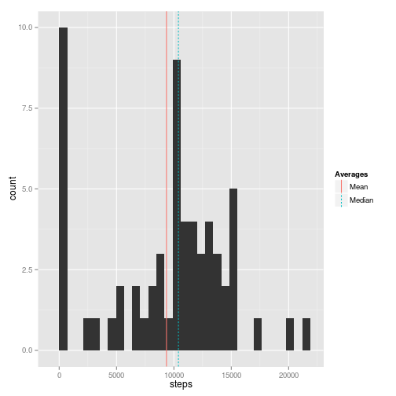

```r
# default ggplot2 histogram, since automatic breaks seems a good compromise
qplot(steps, data = stepsbyday, geom = "histogram", show_guide = T) +
        geom_vline(data = stepsAvg,             # Add vertical lines of mean and
                   aes(xintercept = Values,     #median
                   colour = Averages, linetype = Averages), show_guide = T)
```

Here is presented the histogram -not the barplot, as emphasized in the instructions- **of the single variable** *total steps per day*. This means that the plot presents the count of the days where `x` steps were taken. As you can see there are 9 days with just over 10000 steps taken, or 5 days with just over 15000 steps takes, or 10 days with almost none steps taken, etcetera.

The **mean (9354.23)** of *steps takes per day*, and the **median (10395)** are also ploted as a red and a pointed-green lines respectively.

## What is the average daily activity pattern?

```r
stepsbyint <- activity %>%      # group by interval and calculate mean
        group_by(interval) %>%
        summarize(steps = mean(steps, na.rm = TRUE))
```

```r
maxVal <- max(stepsbyint$steps, na.rm = TRUE)    # Create a little table
maxInt <- stepsbyint$int[which(stepsbyint$steps == maxVal)]
                                                       #max;
labMax <- c("Max")                        #maybe not necessary,
stepsMax <- matrix(nrow = 1, ncol = 3)             #but easier to plot
stepsMax <- data.frame(stepsMax) %>%
        tbl_df() %>%
        mutate(X1 = labMax, X2 = maxVal, X3 = maxInt) %>%
        rename(Stat = X1, yValue = X2, xValue = X3)
```

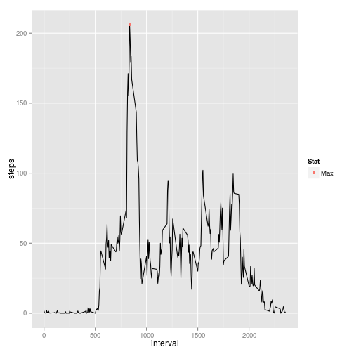

```r
# default ggplot2 line graph
qplot(interval, steps, data = stepsbyint, geom = "line", show_guide = T) +
        geom_point(data = stepsMax,             # Add point for maximum
                   aes(x = xValue, y = yValue, colour = Stat), show_guide = T)
```

## Imputing missing values

```r
NAs <- sum(!complete.cases(activity))
```

There are **2304 missing** values, *i.e.* non-complete cases.

```r
activityImp <- as.data.frame(activity)
imp <- amelia(activityImp, # Impute values with Amelia package
              bound = rbind(c(1, 0, Inf), c(2, 0, Inf), c(3, 0, Inf)))
```

```
## -- Imputation 1 --
##
##   1  2
##
## -- Imputation 2 --
##
##   1  2
##
## -- Imputation 3 --
##
##   1  2
##
## -- Imputation 4 --
##
##   1  2
##
## -- Imputation 5 --
##
##   1  2
```

```r
activityImp1 <- imp[["imputations"]][[1]]
activityImp1 <- tbl_df(activityImp1) %>%
        mutate(steps = as.integer(round(steps, 0))) # round imputations to integer
```

```r
stepsbyday2 <- activityImp1 %>%      # group by date and calculate sum
        group_by(date) %>%
        summarize(steps = sum(steps, na.rm = TRUE))
```

```r
stepsVals2 <- c(mean(stepsbyday2$steps, na.rm = TRUE),    # Create a little table
      median(stepsbyday2$steps, na.rm = TRUE))           #with mean and median;
stepsStat2 <- c("Mean", "Median")                        #maybe not necessary,
stepsAvg2 <- matrix(nrow = 2, ncol = 2)
stepsAvg2 <- data.frame(stepsAvg2) %>%                    #but easier to plot
        tbl_df() %>%
        mutate(X1 = stepsStat2, X2 = stepsVals2) %>%
        rename(Averages = X1, Values = X2)
```

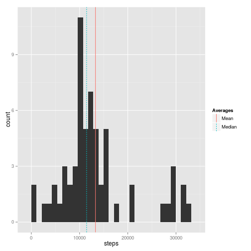

```r
# default ggplot2 histogram, since automatic breaks seems a good compromise
qplot(steps, data = stepsbyday2, geom = "histogram", show_guide = T) +
        geom_vline(data = stepsAvg2,             # Add vertical lines of mean and
                   aes(xintercept = Values,     #median
                   colour = Averages, linetype = Averages), show_guide = T)
```

Here is presented the histogram **of the single variable** *total steps per day*, for the imputed dataset. The **mean (13291.23)** of *steps takes per day*, and the **median (11458)** for imputed dataset are also ploted as a red and a pointed-green lines respectively. With the imputation, both average measures have changed. Nonetheless, the **median increased** 'only' **1063**, while the **mean** has **increased 3937**. The data has changed from being biased towards low numbers (“to the left”), to a bias towards higher numbers (“to the right”).

## Are there differences in activity patterns between weekdays and weekends?

```r
activityWeek <- activityImp1
activityWeek <- tbl_df(activityWeek) %>%        # Creating weekday/end factor
        mutate(weekday = wday(date))
activityWeek <- activityWeek %>%
        mutate(weekend = c(activityWeek$weekday %in% c(7, 1))) %>%
        mutate(weekend = factor(weekend, labels = c("weekday", "weekend")))
```

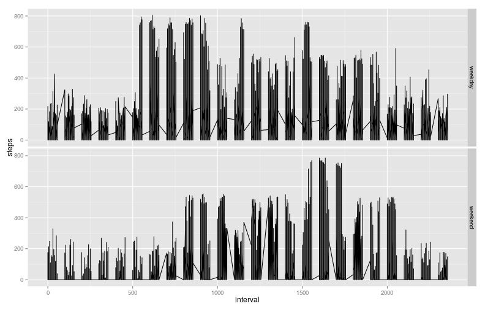

```r
# default ggplot2 line graph with panels or facets by weekday/end
qplot(interval, steps, data = activityWeek, geom = "line", facets = weekend~.)
```